# Machine Learning Project

### Company Bankruptcy Prediction

Names:

```
- Denis Mugisha
- Liu Guangqiang
- Rachel Fanti
```

Dataset: https://www.kaggle.com/fedesoriano/company-bankruptcy-prediction

Data: May/2021

## Libraries

```python
# Basics
%matplotlib inline
import matplotlib.pyplot as plt
import numpy as np
import pandas as pd
import seaborn as sns
```

```python
# Statistic funtions
from numpy.random import seed
from collections import Counter
```

```python
# Preprocessing
from sklearn.preprocessing import StandardScaler
from sklearn.model_selection import train_test_split
from sklearn.model_selection import StratifiedKFold, StratifiedShuffleSplit

# Select Features
from sklearn.tree import DecisionTreeClassifier
from sklearn.feature_selection import SelectFromModel
from sklearn.feature_selection import RFECV
```

```python
# Neural Network
import sklearn
from sklearn.model_selection import GridSearchCV
from sklearn.neural_network import MLPClassifier
# MLPRegressor
```

```python
# Evaluation of the model
from sklearn.metrics import classification_report, confusion_matrix, plot_confusion_matrix, balanced_accuracy_score
from sklearn.metrics import mean_squared_error, roc_curve, auc
from sklearn.model_selection import learning_curve, validation_curve
```

```python
# To handle imbalanced data
import imblearn
from imblearn.over_sampling import SMOTE, RandomOverSampler
from imblearn.under_sampling import RandomUnderSampler
print(imblearn.__version__)
```

```
0.8.0
```

## Reading data

```python
df_complete = pd.read_csv('./data/data.csv', sep = ",")
df_feat = pd.read_csv('./data/bankruptcy.csv')
df_feat
```

|  | Unnamed: 0 | features | importance | select_tree | rank_rfecv | selected_rfecv | corr |
| --- | --- | --- | --- | --- | --- | --- | --- |
| 0 | 47 | Inventory Turnover Rate (times) | 0.001875 | True | 1 | True | 0.012556 |
| 1 | 71 | Quick Asset Turnover Rate | 0.000000 | True | 1 | True | 0.036946 |
| 2 | 61 | Inventory/Working Capital | 0.025644 | True | 1 | True | 0.055539 |
| 3 | 56 | Cash/Total Assets | 0.023681 | True | 1 | True | 0.150828 |
| 4 | 55 | Current Assets/Total Assets | 0.003832 | True | 1 | True | 0.044232 |
| ... | ... | ... | ... | ... | ... | ... | ... |
| 90 | 2 | ROA(B) before interest and depreciation after... | 0.000000 | False | 71 | False | 0.224163 |
| 91 | 48 | Fixed Assets Turnover Frequency | 0.000000 | True | 72 | False | 0.047546 |
| 92 | 32 | Current Ratio | 0.000000 | False | 73 | False | 0.189644 |
| 93 | 1 | ROA(A) before interest and % after tax | 0.000000 | False | 74 | False | 0.222410 |
| 94 | 0 | ROA(C) before interest and depreciation befor... | 0.008929 | False | 75 | False | 0.223589 |

95 rows × 7 columns

```python
col = df_feat[df_feat['selected_rfecv']==True]['features'].values
col = np.insert(col, 0, 'Bankrupt?')
print(col)
```

```
['Bankrupt?' ' Inventory Turnover Rate (times)'
 ' Quick Asset Turnover Rate' ' Inventory/Working Capital'
 ' Cash/Total Assets' ' Current Assets/Total Assets'
 ' Allocation rate per person' ' Net profit before tax/Paid-in capital'
 ' Borrowing dependency' ' Net worth/Assets' ' Interest Expense Ratio'
 ' Cash Reinvestment %' ' Net Value Growth Rate'
 ' Net Value Per Share (B)' ' Current Liability to Current Assets'
 ' Interest-bearing debt interest rate'
 " Net Income to Stockholder's Equity"
 ' Degree of Financial Leverage (DFL)' ' Total assets to GNP price'
 ' Non-industry income and expenditure/revenue' ' Operating Expense Rate'
 ' Research and development expense rate']
```

```python
df = df_complete.loc[:, col]
```

```python
# pd.set_option('display.max_columns', None)
# df
df.shape
```

```
(6819, 22)
```

### Splitting data into train/ validate/ test sets

```python
X = df.iloc[:,1:]
y = df.iloc[:,0]
```

```python
# Split into train and val/test sets
X_train_all, X_aux_all, y_train, y_aux = train_test_split (X, y, test_size=0.40, random_state=1, stratify=y)
X_val_all, X_test_all, y_val, y_test = train_test_split (X_aux_all, y_aux, test_size=0.50, random_state=2, stratify=y_aux)
```

```python
print(f"y_train = {Counter (y_train)}")
print(f"                   0: {Counter(y_train)[0]/len(y_train):.0%},  1: {Counter(y_train)[1]/len(y_train):.0%}")
print()
print(f"y_val = {Counter (y_val)}")
print(f"                  0: {Counter(y_val)[0]/len(y_val):.0%},  1: {Counter(y_val)[1]/len(y_val):.0%}")
print()
print(f"y_test = {Counter (y_test)}")
print(f"                  0: {Counter(y_test)[0]/len(y_test):.0%},  1: {Counter(y_test)[1]/len(y_test):.0%}")
```

```
y_train = Counter({0: 3959, 1: 132})
                   0: 97%,  1: 3%

y_val = Counter({0: 1320, 1: 44})
                  0: 97%,  1: 3%

y_test = Counter({0: 1320, 1: 44})
                  0: 97%,  1: 3%
```

```python
n_feat = X_train_all.shape[1]
X_train = X_train_all.iloc[:,0:n_feat] # selecting the number of features
X_val = X_val_all.iloc[:,0:n_feat] # selecting the number of features
X_test = X_test_all.iloc[:,0:n_feat] # selecting the number of features
```

## Standardization for neural network

To avoid the effect of one feature dominating the other, it will be performed feature scaling, standardizing our data to have mean 0 and variance 1. Note that we must apply the same scaling to the test set for meaningful results.

```python
def feature_scaling(X_train, X_test):
    scaler = StandardScaler()
    scaler.fit(X_train)
    X_train = scaler.transform(X_train)  # to include in pipeline?
    X_test = scaler.transform(X_test)
    return (X_train, X_test)
```

```python
X_train, X_val = feature_scaling(X_train, X_val)
print(X_train.shape)
# print(X_train)
# print (X_train.mean(axis=0).round(2))
# print (X_train.std(axis=0))
```

```
(4091, 21)
```

## Neural Network

In this step, we will build the neural network model using the scikit-learn library's estimator object, 'Multi-Layer Perceptron Classifier'. Class MLPClassifier implements a multi-layer perceptron (MLP) algorithm that trains using Backpropagation.

[figure not shown]

We will start including all features selected, and considering only one layer.

```python
def neural_network(X_train, y_train, X_test, param_grid =
                    {'hidden_layer_sizes': [n_feat], 'activation': ['relu'], 'solver': ['adam']}):

    '''Train a neural network (input: X_train, y_train and parameters) and predict (X_Test)
        The parameters can be informed in GridSearchCV to select the best estimator'''

    #Choose the classifier
    mlp = MLPClassifier(max_iter=2000, random_state=42)

    #Run the search:
    clf = GridSearchCV(mlp, param_grid, scoring='balanced_accuracy') #cv=StratifiedKFold(n_splits=5)

    clf.fit(X_train,y_train)

    predict_train = clf.predict(X_train)
    predict_test = clf.predict(X_test)

    return clf.best_estimator_, clf, predict_train, predict_test
```

```python
# Define the parameters for the neural network
clf, clf_grid, predict_train, predict_val = neural_network(X_train, y_train, X_val)
```

```python
def print_results_grid(clf, predict_train, predict_test):

    '''Print the results of the best parameters found in a neural network and the the others results'''

    #Best parametes set
    print('Best parameters found:\n', clf.best_params_)

    #All results
    means = clf.cv_results_['mean_test_score']
    stds = clf.cv_results_['std_test_score']
    for mean, std, params in zip(means, stds, clf.cv_results_['params']):
        print("%0.3f (+/-%0.03f) for %r" % (mean, std * 2, params))
```

```python
print_results_grid(clf_grid, predict_train, predict_val)
```

```
Best parameters found:
 {'activation': 'relu', 'hidden_layer_sizes': 21, 'solver': 'adam'}
0.584 (+/-0.063) for {'activation': 'relu', 'hidden_layer_sizes': 21, 'solver': 'adam'}
```

```python
def print_results_neural_network(clf, predict_train, predict_test):

    '''Print the results of the neural network'''

    # coefs_list of shape (n_layers - 1,) - weight matrix corresponding to layer i (thetas)
    # intercepts_list of shape (n_layers - 1,) - bias vector corresponding to layer i + 1 (a)

    print('Weight matrix:')
    print('Shape:', [coef.shape for coef in clf.coefs_])
    # print('Clf coeficients:', clf.coefs_)
    # print()
    # print ('Clf intercepts:', clf.intercepts_)
    print()

    # Loss of each step (snapshot of the training process and the direction in which the network learns)
    print('Loss curve:')
    plt.plot(clf.loss_curve_)
    plt.show()
    print('Best loss', clf.best_loss_)

    # print results predicted

    # np.set_printoptions(threshold=np.inf)
    # print (predict_train)
    # print (predict_test)
    # np.set_printoptions(threshold=1000)
```

```
Weight matrix:
Shape: [(21, 21), (21, 1)]

Loss curve:
```

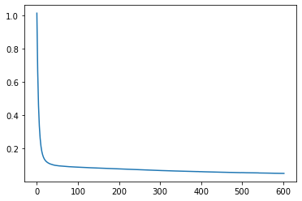

```
Best loss 0.05002350751888141
```

```python
print_results_neural_network(clf, predict_train, predict_val)
```

### Evaluation the Algorithm

**Confusion matrix:**

- True positives: positive tuples correctly labeled
- True negatives: negative tuples correctly labeled
- False positives: negative tuples incorrectly labeled
- False negatives: positive tuples incorrectly labeled

**Classification report:**

- Accuracy = (TP+TN)/(TP+TN+FP+FN)
- Precision = TP/(TP+FP)
- Recall = TP/(TP+FN)
- F1 - measure = 2rp/(r+p)
- WeightedAccuracy = (Wtp*TP+Wtn*TN)/(Wtp*TP+Wtn*TN+Wfp*FP+Wfn*FN)

**Error:**

- Mean squared error (MSE)

**Receiver Operating Characteristic (ROC) curve:**

- Area Under the Curve (AUC)

```python
df_results = pd.DataFrame(columns = ['Scenarios','#Features', 'Train/Test', 'Acc', 'Bal_Acc','M_P','M_R', 'M_F1', "P0", "P1", "R0", "R1", 'MSE', 'Auc'])
print (df_results)
```

```
Empty DataFrame
Columns: [Scenarios, #Features, Train/Test, Acc, Bal_Acc, M_P, M_R, M_F1, P0, P1, R0, R1, MSE, Auc]
Index: []
```

```python
def evaluation_set(clf, y, predict, df_results, type_set, scenario_name, n_feat):

    '''Calculate metrics given a scenario and set (train/validatioon or test set)'''

    # Classification report
    report = classification_report(y, predict, output_dict=True)
    accuracy = round(report['accuracy'], 2)
    balanced_accuracy = round(balanced_accuracy_score(y, predict), 2)
    macro_precision =  round(report['macro avg']['precision'],2)
    macro_recall = round(report['macro avg']['recall'], 2)
    macro_f1 = round(report['macro avg']['f1-score'], 2)
    p0 = round(report['0']['precision'], 2)
    p1 = round(report['1']['precision'], 2)
    r0 = round(report['0']['recall'], 2)
    r1 = round(report['1']['recall'], 2)

    # MSE - Mean squared error
    mse = round(mean_squared_error (y,predict),3)

    # AUC
    fpr, tpr, thresh = roc_curve(y, predict)
    area = round(auc(fpr, tpr),2)

    df_results.loc[len(df_results)+1] = [scenario_name, str(n_feat) + ' features', type_set, accuracy, balanced_accuracy,
                                         macro_precision, macro_recall, macro_f1, p0, p1, r0, r1, mse, area]
```

```python
def evaluation_scenario(clf, y_train, y_test, predict_train, predict_test, df_results, scenario_name, n_feat):
    evaluation_set(clf, y_train, predict_train, df_results,'Train', scenario_name, n_feat)
    evaluation_set(clf, y_test, predict_test, df_results,'Val/Test', scenario_name, n_feat)
```

```python
evaluation_scenario(clf, y_train, y_val, predict_train, predict_val, df_results, 'Set-00', n_feat)
```

```python
def print_confusion_matrix(clf, X, y, type_set):

    # Confusion matrix

    print(f'Confusion matrix - {type_set}:')
    plot_confusion_matrix(clf, X, y)
    plt.show()
```

```python
def print_classification_report(clf, y, predict, type_set):

    print(f'Classification Report - {type_set}:')
    print(classification_report(y, predict))
    print()
    print ('MSE - {type_set}:', round(mean_squared_error (y,predict),3))
```

```python
def plot_roc_curve(y, predict, type_set):

    fpr, tpr, thresh = roc_curve(y, predict)
    area = auc(fpr, tpr)

    plt.plot(fpr, tpr, label='ROC curve (area = %.2f)' %area)
    plt.plot([0, 1], [0, 1], linestyle='--', lw=2, color='r', label='Random guess')
    plt.title(f'AUC & ROC curve - {type_set}')
    plt.xlabel('False Positive Rate')
    plt.ylabel('True Positive Rate')
    plt.grid()
    plt.legend()
    plt.show()
```

```python
def print_evaluation_scenario(clf, X_train, y_train, X_test, y_test, predict_train, predict_test):

    # print_confusion_matrix(clf, X_train, y_train, 'Train')
    conf_matrix = print_confusion_matrix(clf, X_test, y_test, 'Val/Test')
    # print_classification_report(clf, y_train, predict_train, 'Train')
    print_classification_report(clf, y_test, predict_test, 'Val/Test')
    # plot_roc_curve(y_train, predict_train, 'Train')
    roc = plot_roc_curve(y_test, predict_test, 'Val/Test')
```

```
Confusion matrix - Val/Test:
```

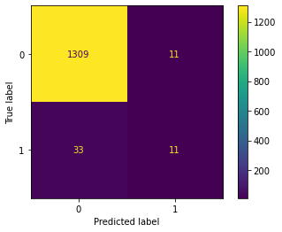

```
Classification Report - Val/Test:
              precision    recall  f1-score   support

           0       0.98      0.99      0.98      1320
           1       0.50      0.25      0.33        44

    accuracy                           0.97      1364
   macro avg       0.74      0.62      0.66      1364
weighted avg       0.96      0.97      0.96      1364


MSE - {type_set}: 0.032
```

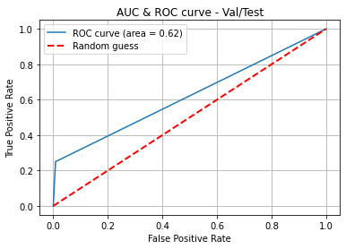

```python
print_evaluation_scenario(clf, X_train, y_train, X_val, y_val, predict_train, predict_val)
```

**Learning curve:**

```python
def plot_learning_curve(estimator, X, y, ylim=None, n_jobs=None, train_sizes=np.linspace(.1, 1.0, 5)):

    #cv = StratifiedShuffleSplit(n_splits=10, test_size=0.2, random_state=0)
    cv = StratifiedKFold(n_splits=5, random_state=None, shuffle=False) # cv = 5, instead of 10 to avoid samples without class 1

    train_sizes, train_scores, test_scores = learning_curve(estimator, X, y, scoring='balanced_accuracy', cv=cv, n_jobs=n_jobs, train_sizes=train_sizes)

    train_scores_mean = np.mean(train_scores, axis=1)
    train_scores_std = np.std(train_scores, axis=1)
    test_scores_mean = np.mean(test_scores, axis=1)
    test_scores_std = np.std(test_scores, axis=1)

    print(f'#Cv - Train: {train_scores.shape} - Test: {test_scores.shape}\n')
    print('Train and test scores according to the sample size\n')
    print('Train: {0}'.format(train_scores_mean))
    print('Test:  {0}'.format(test_scores_mean))

    title = "Learning Curve for Multi Layer Preceptron (MLP)\n" \
        "Cross Validation of {cv} splits\n"

    plt.figure()
    plt.title(title)
    if ylim is not None:
        plt.ylim(*ylim)
    plt.xlabel("Number of training examples")
    plt.ylabel("Balanced Accuracy Score")

    #plt.grid()
    plt.plot(train_sizes, train_scores_mean, 'o-', color="r", label="Training score")
    plt.plot(train_sizes, test_scores_mean, 'o-', color="g", label="Testing score")
    plt.fill_between(train_sizes, train_scores_mean - train_scores_std,train_scores_mean + train_scores_std, alpha=0.1,color="r")
    plt.fill_between(train_sizes, test_scores_mean - test_scores_std,test_scores_mean + test_scores_std, alpha=0.1, color="g")
    plt.legend(loc='best')
    plt.show()
```

```
#Cv - Train: (5, 5) - Test: (5, 5)

Train and test scores according to the sample size

Train: [0.89179487 0.7747298  0.68867683 0.80915683 0.76762589]
Test:  [0.57501411 0.57601578 0.54880796 0.5982623  0.58442633]
```

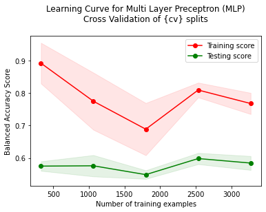

```python
plot_learning_curve(clf, X_train, y_train) # ylim=(0.7, 1.01)
```

```python
df_results
```

|  | Scenarios | #Features | Train/Test | Acc | Bal_Acc | M_P | M_R | M_F1 | P0 | P1 | R0 | R1 | MSE | Auc |
| --- | --- | --- | --- | --- | --- | --- | --- | --- | --- | --- | --- | --- | --- | --- |
| 1 | Set-00 | 21 features | Train | 0.98 | 0.76 | 0.95 | 0.76 | 0.83 | 0.98 | 0.92 | 1.00 | 0.52 | 0.017 | 0.76 |
| 2 | Set-00 | 21 features | Val/Test | 0.97 | 0.62 | 0.74 | 0.62 | 0.66 | 0.98 | 0.50 | 0.99 | 0.25 | 0.032 | 0.62 |

### Analysis of scenarios

We will start analysing the results for a neural network considering 5, 10, 15 and 21 (all) features

[figure not shown]

The next scenarios will be defined analysing the results.

If testing the hypothesis results in a high error rate:  
• Get more training examples (when there is a high variance (overfitting))  
• Try smaller sets of features (when there is a high variance (overfitting))  
• Try getting additional features (when there is a high bias (underfitting))  
• Try adding polynomial features (when there is a high bias (underfitting))  
• Try decreasing 𝜆 (when there is a high bias (underfitting))  
• Try increasing 𝜆 (when there is a high variance (overfitting))

Neural Networks tend to overfit the data: use regularization  
Use model selection to decide the structure of your network (how many hidden layers)

```python
df_results_ = pd.DataFrame(columns = ['Scenarios','Selected Features', 'Train/Test', 'Bal_Acc','M_P','M_R', 'M_F1', "P0", "P1", "R0", "R1", 'MSE', 'Auc'])
print (df_results)
```

```
  Scenarios    #Features Train/Test   Acc  Bal_Acc   M_P   M_R  M_F1    P0  \
1    Set-00  21 features      Train  0.98     0.76  0.95  0.76  0.83  0.98
2    Set-00  21 features   Val/Test  0.97     0.62  0.74  0.62  0.66  0.98

     P1    R0    R1    MSE   Auc
1  0.92  1.00  0.52  0.017  0.76
2  0.50  0.99  0.25  0.032  0.62
```

```python
param_basic = {'hidden_layer_sizes': [n_feat], 'activation': ['relu'], 'solver': ['adam']}


def avalia_scenario(X_train_all, X_test_all, y_train, y_test, df_results, n_feat, scenario_name, param_grid=param_basic, scen=0):

    # selecting the number of features for X_train and X_test
    X_train = X_train_all.iloc[:,0:n_feat]
    X_test = X_test_all.iloc[:,0:n_feat] # selecting the number of features

    # feature scaling
    X_train, X_test = feature_scaling(X_train, X_test)

    # Train neural network, selecting the best parameters when necessary
    clf, clf_grid, predict_train, predict_test = neural_network(X_train, y_train, X_test, param_grid) # training neural network

    # show the results of the scenarios and the best option when analyzing the parameters
    if scen==0:
        print_results_grid(clf_grid, predict_train, predict_test)

    # evaluate the model and include results in the spreadsheet
    evaluation_scenario(clf, y_train, y_test, predict_train, predict_test, df_results, scenario_name, n_feat) # evaluation model
    print_evaluation_scenario(clf, X_train, y_train, X_test, y_test, predict_train, predict_test)
    plot_learning_curve(clf, X_train, y_train)
    if scen==2:
        print_evaluation_scenario(clf, X_train, y_train, X_test, y_test, predict_train, predict_test) # print results
    print
```

**Evaluation of parameters of the model:**

1. activation: 'tanh' or 'relu'?
2. solver: 'sgd' or 'adam'?
3. learning_rate: 'constant' or 'adaptive'?

```
Best parameters found:
 {'activation': 'tanh', 'hidden_layer_sizes': [21], 'learning_rate': 'constant', 'solver': 'adam'}
0.522 (+/-0.046) for {'activation': 'relu', 'hidden_layer_sizes': [21], 'learning_rate': 'constant', 'solver': 'sgd'}
0.584 (+/-0.063) for {'activation': 'relu', 'hidden_layer_sizes': [21], 'learning_rate': 'constant', 'solver': 'adam'}
0.522 (+/-0.046) for {'activation': 'relu', 'hidden_layer_sizes': [21], 'learning_rate': 'adaptive', 'solver': 'sgd'}
0.584 (+/-0.063) for {'activation': 'relu', 'hidden_layer_sizes': [21], 'learning_rate': 'adaptive', 'solver': 'adam'}
0.539 (+/-0.046) for {'activation': 'tanh', 'hidden_layer_sizes': [21], 'learning_rate': 'constant', 'solver': 'sgd'}
0.611 (+/-0.077) for {'activation': 'tanh', 'hidden_layer_sizes': [21], 'learning_rate': 'constant', 'solver': 'adam'}
0.539 (+/-0.046) for {'activation': 'tanh', 'hidden_layer_sizes': [21], 'learning_rate': 'adaptive', 'solver': 'sgd'}
0.611 (+/-0.077) for {'activation': 'tanh', 'hidden_layer_sizes': [21], 'learning_rate': 'adaptive', 'solver': 'adam'}
Confusion matrix - Val/Test:
```

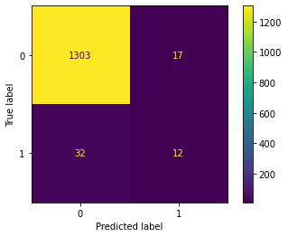

```
Classification Report - Val/Test:
              precision    recall  f1-score   support

           0       0.98      0.99      0.98      1320
           1       0.41      0.27      0.33        44

    accuracy                           0.96      1364
   macro avg       0.69      0.63      0.66      1364
weighted avg       0.96      0.96      0.96      1364


MSE - {type_set}: 0.036
```

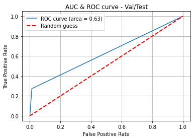

```
#Cv - Train: (5, 5) - Test: (5, 5)

Train and test scores according to the sample size

Train: [0.82898252 0.86005865 0.85166697 0.8744731  0.85128981]
Test:  [0.61089472 0.56771662 0.57189348 0.58790941 0.59612311]
```

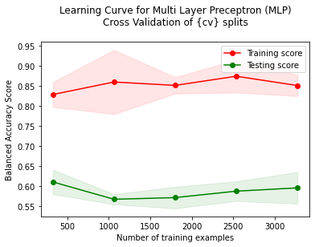

```python
param_grid = {
        'hidden_layer_sizes': [[(n_feat)]],
        'activation': ['relu', 'tanh'],
        'solver': ['sgd', 'adam'],
        'learning_rate': ['constant','adaptive'],
}

avalia_scenario(X_train_all, X_val_all, y_train, y_val, df_results, 21, 'param_grid', param_grid, scen=0)
```

The best parameters selected were listed above.

However, as the results were close, we intend to keep the default.

- Activation function 'Relu' because is computationally efficient, allows the network to converge very quickly.
- Solver ‘adam’ because it works pretty well on relatively large datasets (in terms of both training time and validation score).
- Learning_rate: constant.

**Scenario basic - 5 features**

```
Best parameters found:
 {'activation': 'relu', 'hidden_layer_sizes': 21, 'solver': 'adam'}
0.500 (+/-0.000) for {'activation': 'relu', 'hidden_layer_sizes': 21, 'solver': 'adam'}
Confusion matrix - Val/Test:
```

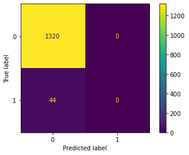

```
Classification Report - Val/Test:
              precision    recall  f1-score   support

           0       0.97      1.00      0.98      1320
           1       0.00      0.00      0.00        44

    accuracy                           0.97      1364
   macro avg       0.48      0.50      0.49      1364
weighted avg       0.94      0.97      0.95      1364


MSE - {type_set}: 0.032
```

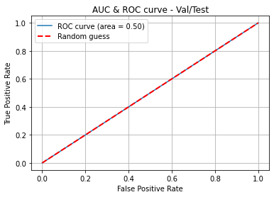

```
#Cv - Train: (5, 5) - Test: (5, 5)

Train and test scores according to the sample size

Train: [0.5 0.5 0.5 0.5 0.5]
Test:  [0.5 0.5 0.5 0.5 0.5]
```

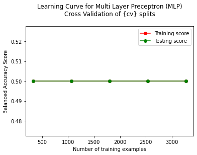

```python
avalia_scenario (X_train_all, X_val_all, y_train, y_val, df_results, 5, 'NN0-05')
```

**Scenario basic - 10 features**

```
Best parameters found:
 {'activation': 'relu', 'hidden_layer_sizes': 21, 'solver': 'adam'}
0.532 (+/-0.049) for {'activation': 'relu', 'hidden_layer_sizes': 21, 'solver': 'adam'}
Confusion matrix - Val/Test:
```

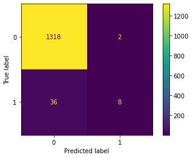

```
Classification Report - Val/Test:
              precision    recall  f1-score   support

           0       0.97      1.00      0.99      1320
           1       0.80      0.18      0.30        44

    accuracy                           0.97      1364
   macro avg       0.89      0.59      0.64      1364
weighted avg       0.97      0.97      0.96      1364


MSE - {type_set}: 0.028
```

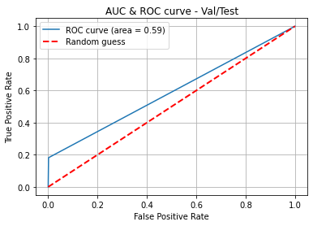

```
#Cv - Train: (5, 5) - Test: (5, 5)

Train and test scores according to the sample size

Train: [0.71000817 0.59054379 0.56853571 0.57523204 0.57317567]
Test:  [0.56319818 0.53897582 0.54282214 0.52756346 0.53948103]
```

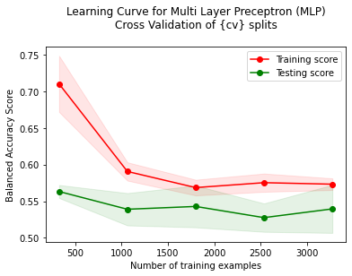

```python
avalia_scenario (X_train_all, X_val_all, y_train, y_val, df_results, 10, 'NN0-10')
```

**Scenario basic - 15 features**

```
Best parameters found:
 {'activation': 'relu', 'hidden_layer_sizes': 21, 'solver': 'adam'}
0.549 (+/-0.043) for {'activation': 'relu', 'hidden_layer_sizes': 21, 'solver': 'adam'}
Confusion matrix - Val/Test:
```

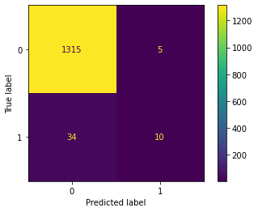

```
Classification Report - Val/Test:
              precision    recall  f1-score   support

           0       0.97      1.00      0.99      1320
           1       0.67      0.23      0.34        44

    accuracy                           0.97      1364
   macro avg       0.82      0.61      0.66      1364
weighted avg       0.96      0.97      0.96      1364


MSE - {type_set}: 0.029
```

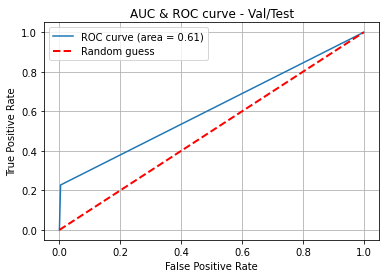

```
#Cv - Train: (5, 5) - Test: (5, 5)

Train and test scores according to the sample size

Train: [0.86641842 0.68375069 0.64187801 0.66243217 0.63065101]
Test:  [0.58537476 0.55040389 0.54936141 0.54192163 0.54168545]
```

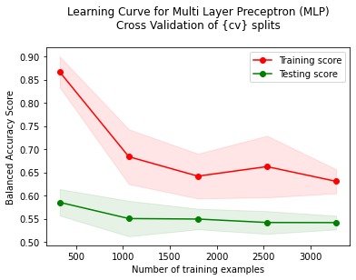

```python
avalia_scenario (X_train_all, X_val_all, y_train, y_val, df_results, 15, 'NN0-15')
```

**Scenario basic - 21 features**

```
Best parameters found:
 {'activation': 'relu', 'hidden_layer_sizes': 21, 'solver': 'adam'}
0.584 (+/-0.063) for {'activation': 'relu', 'hidden_layer_sizes': 21, 'solver': 'adam'}
Confusion matrix - Val/Test:
```

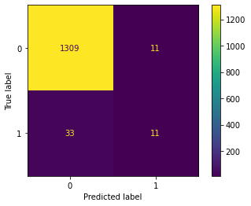

```
Classification Report - Val/Test:
              precision    recall  f1-score   support

           0       0.98      0.99      0.98      1320
           1       0.50      0.25      0.33        44

    accuracy                           0.97      1364
   macro avg       0.74      0.62      0.66      1364
weighted avg       0.96      0.97      0.96      1364


MSE - {type_set}: 0.032
```

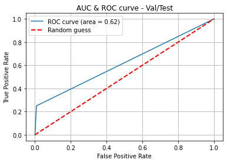

```
#Cv - Train: (5, 5) - Test: (5, 5)

Train and test scores according to the sample size

Train: [0.89179487 0.7747298  0.68867683 0.80915683 0.76762589]
Test:  [0.57501411 0.57601578 0.54880796 0.5982623  0.58442633]
```

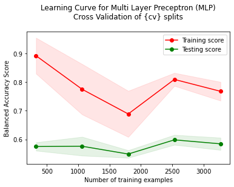

```python
avalia_scenario (X_train_all, X_val_all, y_train, y_val, df_results, 21, 'NN0-21')
```

```python
df_results
```

|  | Scenarios | #Features | Train/Test | Acc | Bal_Acc | M_P | M_R | M_F1 | P0 | P1 | R0 | R1 | MSE | Auc |
| --- | --- | --- | --- | --- | --- | --- | --- | --- | --- | --- | --- | --- | --- | --- |
| 1 | Set-00 | 21 features | Train | 0.98 | 0.76 | 0.95 | 0.76 | 0.83 | 0.98 | 0.92 | 1.00 | 0.52 | 0.017 | 0.76 |
| 2 | Set-00 | 21 features | Val/Test | 0.97 | 0.62 | 0.74 | 0.62 | 0.66 | 0.98 | 0.50 | 0.99 | 0.25 | 0.032 | 0.62 |
| 3 | param_grid | 21 features | Train | 0.99 | 0.82 | 0.96 | 0.82 | 0.88 | 0.99 | 0.92 | 1.00 | 0.64 | 0.013 | 0.82 |
| 4 | param_grid | 21 features | Val/Test | 0.96 | 0.63 | 0.69 | 0.63 | 0.66 | 0.98 | 0.41 | 0.99 | 0.27 | 0.036 | 0.63 |
| 5 | NN0-05 | 5 features | Train | 0.97 | 0.50 | 0.48 | 0.50 | 0.49 | 0.97 | 0.00 | 1.00 | 0.00 | 0.032 | 0.50 |
| 6 | NN0-05 | 5 features | Val/Test | 0.97 | 0.50 | 0.48 | 0.50 | 0.49 | 0.97 | 0.00 | 1.00 | 0.00 | 0.032 | 0.50 |
| 7 | NN0-10 | 10 features | Train | 0.97 | 0.55 | 0.73 | 0.55 | 0.57 | 0.97 | 0.48 | 1.00 | 0.10 | 0.033 | 0.55 |
| 8 | NN0-10 | 10 features | Val/Test | 0.97 | 0.59 | 0.89 | 0.59 | 0.64 | 0.97 | 0.80 | 1.00 | 0.18 | 0.028 | 0.59 |
| 9 | NN0-15 | 15 features | Train | 0.97 | 0.58 | 0.78 | 0.58 | 0.62 | 0.97 | 0.58 | 1.00 | 0.17 | 0.031 | 0.58 |
| 10 | NN0-15 | 15 features | Val/Test | 0.97 | 0.61 | 0.82 | 0.61 | 0.66 | 0.97 | 0.67 | 1.00 | 0.23 | 0.029 | 0.61 |
| 11 | NN0-21 | 21 features | Train | 0.98 | 0.76 | 0.95 | 0.76 | 0.83 | 0.98 | 0.92 | 1.00 | 0.52 | 0.017 | 0.76 |
| 12 | NN0-21 | 21 features | Val/Test | 0.97 | 0.62 | 0.74 | 0.62 | 0.66 | 0.98 | 0.50 | 0.99 | 0.25 | 0.032 | 0.62 |

NN0-5 features >> underfittting  
NN0-10 features >> Best Acc, M_P, P1, R0, MSE  
NN0-15 features >> Best M_F1  
NN0-21 features >> Best Bal_Acc, M_R, P0, R1

**Scenario - Hidden layers**

```
Best parameters found:
 {'hidden_layer_sizes': (10, 10, 10, 10, 10)}
0.532 (+/-0.052) for {'hidden_layer_sizes': 10}
0.537 (+/-0.070) for {'hidden_layer_sizes': (10, 10)}
0.584 (+/-0.109) for {'hidden_layer_sizes': (10, 10, 10)}
0.570 (+/-0.105) for {'hidden_layer_sizes': (10, 10, 10, 10)}
0.606 (+/-0.068) for {'hidden_layer_sizes': (10, 10, 10, 10, 10)}
0.572 (+/-0.063) for {'hidden_layer_sizes': (10, 10, 10, 10, 10, 10)}
Confusion matrix - Val/Test:
```

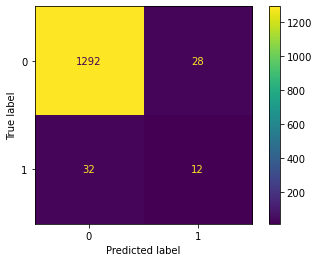

```
Classification Report - Val/Test:
              precision    recall  f1-score   support

           0       0.98      0.98      0.98      1320
           1       0.30      0.27      0.29        44

    accuracy                           0.96      1364
   macro avg       0.64      0.63      0.63      1364
weighted avg       0.95      0.96      0.95      1364


MSE - {type_set}: 0.044
```

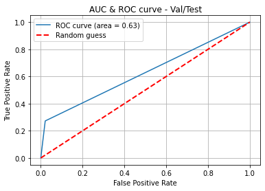

```
#Cv - Train: (5, 5) - Test: (5, 5)

Train and test scores according to the sample size

Train: [1.         0.96927016 0.86260794 0.79575217 0.78705806]
Test:  [0.58509957 0.59237944 0.60932873 0.59156487 0.59351533]
```

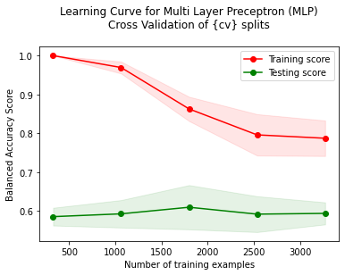

```python
n_feat = 10

param_grid = {
        'hidden_layer_sizes': [(n_feat), (n_feat, n_feat), (n_feat, n_feat, n_feat), (n_feat, n_feat, n_feat,n_feat), (n_feat, n_feat, n_feat, n_feat, n_feat), (n_feat, n_feat, n_feat, n_feat, n_feat, n_feat)]}

avalia_scenario(X_train_all, X_val_all, y_train, y_val, df_results, n_feat, 'hid-10', param_grid, scen=0)
```

```
Best parameters found:
 {'hidden_layer_sizes': (15, 15, 15, 15)}
0.549 (+/-0.030) for {'hidden_layer_sizes': 15}
0.614 (+/-0.031) for {'hidden_layer_sizes': (15, 15)}
0.624 (+/-0.056) for {'hidden_layer_sizes': (15, 15, 15)}
0.638 (+/-0.016) for {'hidden_layer_sizes': (15, 15, 15, 15)}
0.622 (+/-0.082) for {'hidden_layer_sizes': (15, 15, 15, 15, 15)}
Confusion matrix - Val/Test:
```

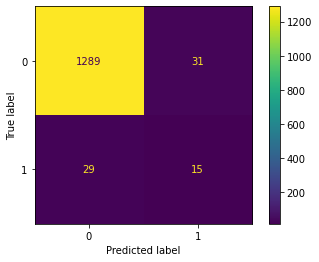

```
Classification Report - Val/Test:
              precision    recall  f1-score   support

           0       0.98      0.98      0.98      1320
           1       0.33      0.34      0.33        44

    accuracy                           0.96      1364
   macro avg       0.65      0.66      0.66      1364
weighted avg       0.96      0.96      0.96      1364


MSE - {type_set}: 0.044
```

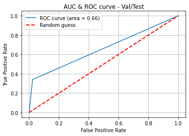

```
#Cv - Train: (5, 5) - Test: (5, 5)

Train and test scores according to the sample size

Train: [0.96923077 0.98888404 0.99810345 0.98066983 0.93549302]
Test:  [0.59766305 0.60947929 0.60719813 0.60960683 0.62387499]
```

```python
n_feat = 15

param_grid = {
        'hidden_layer_sizes': [(n_feat), (n_feat, n_feat), (n_feat, n_feat, n_feat), (n_feat, n_feat, n_feat,n_feat), (n_feat, n_feat, n_feat, n_feat, n_feat)]}

avalia_scenario(X_train_all, X_val_all, y_train, y_val, df_results, n_feat, 'hid-15', param_grid, scen=0)
```

```
Best parameters found:
 {'hidden_layer_sizes': (21, 21)}
0.584 (+/-0.063) for {'hidden_layer_sizes': 21}
0.654 (+/-0.065) for {'hidden_layer_sizes': (21, 21)}
0.638 (+/-0.075) for {'hidden_layer_sizes': (21, 21, 21)}
0.623 (+/-0.071) for {'hidden_layer_sizes': (21, 21, 21, 21)}
0.625 (+/-0.070) for {'hidden_layer_sizes': (21, 21, 21, 21, 21)}
Confusion matrix - Val/Test:
```

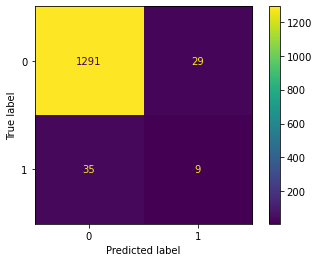

```
Classification Report - Val/Test:
              precision    recall  f1-score   support

           0       0.97      0.98      0.98      1320
           1       0.24      0.20      0.22        44

    accuracy                           0.95      1364
   macro avg       0.61      0.59      0.60      1364
weighted avg       0.95      0.95      0.95      1364


MSE - {type_set}: 0.047
```

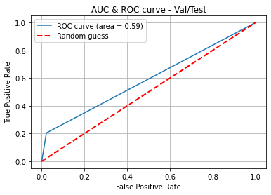

```
#Cv - Train: (5, 5) - Test: (5, 5)

Train and test scores according to the sample size

Train: [1.         1.         0.99830508 0.99244531 0.99228589]
Test:  [0.60741812 0.5871193  0.58655337 0.6129672  0.65024445]
```

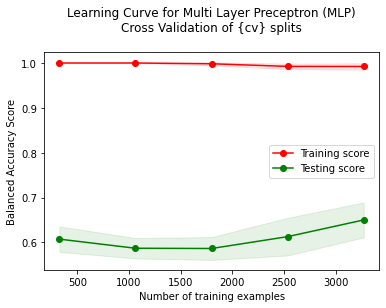

```python
n_feat = 21

param_grid = {
        'hidden_layer_sizes': [(n_feat), (n_feat, n_feat), (n_feat, n_feat, n_feat), (n_feat, n_feat, n_feat,n_feat), (n_feat, n_feat, n_feat, n_feat, n_feat)]}

avalia_scenario(X_train_all, X_val_all, y_train, y_val, df_results, n_feat, 'hid-21', param_grid, scen=0)
```

**Scenario - Regularization term**

```
Best parameters found:
 {'alpha': 0.0001, 'hidden_layer_sizes': (15, 15, 15, 15)}
0.621 (+/-0.043) for {'alpha': 0.1, 'hidden_layer_sizes': (15, 15, 15, 15)}
0.624 (+/-0.037) for {'alpha': 0.01, 'hidden_layer_sizes': (15, 15, 15, 15)}
0.621 (+/-0.096) for {'alpha': 0.001, 'hidden_layer_sizes': (15, 15, 15, 15)}
0.638 (+/-0.016) for {'alpha': 0.0001, 'hidden_layer_sizes': (15, 15, 15, 15)}
0.596 (+/-0.018) for {'alpha': 1e-05, 'hidden_layer_sizes': (15, 15, 15, 15)}
0.591 (+/-0.054) for {'alpha': 1e-06, 'hidden_layer_sizes': (15, 15, 15, 15)}
Confusion matrix - Val/Test:
```

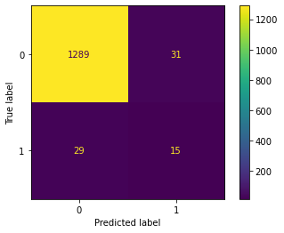

```
Classification Report - Val/Test:
              precision    recall  f1-score   support

           0       0.98      0.98      0.98      1320
           1       0.33      0.34      0.33        44

    accuracy                           0.96      1364
   macro avg       0.65      0.66      0.66      1364
weighted avg       0.96      0.96      0.96      1364


MSE - {type_set}: 0.044
```

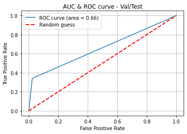

```
#Cv - Train: (5, 5) - Test: (5, 5)

Train and test scores according to the sample size

Train: [0.96923077 0.98888404 0.99810345 0.98066983 0.93549302]
Test:  [0.59766305 0.60947929 0.60719813 0.60960683 0.62387499]
```

```python
n_feat = 15

param_grid = {
        'hidden_layer_sizes': [(n_feat, n_feat, n_feat, n_feat)],
        'alpha': [(10**(-1)),(10**(-2)),(10**(-3)),(10**(-4)),(10**(-5)),(10**(-6))]} # L2 penalty parameter (regularization term)
                                                                    # 10.0 ** -np.arange(1, 7) - scikit-learn

avalia_scenario(X_train_all, X_val_all, y_train, y_val, df_results, n_feat, 'reg-15', param_grid, scen=0)
```

**Scenario - More Units in hidden layers**

```
Best parameters found:
 {'hidden_layer_sizes': (30, 30, 30, 30)}
0.599 (+/-0.104) for {'hidden_layer_sizes': (30, 30, 30, 30)}
Confusion matrix - Val/Test:
```

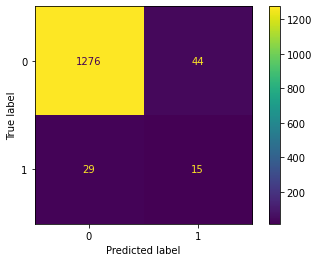

```
Classification Report - Val/Test:
              precision    recall  f1-score   support

           0       0.98      0.97      0.97      1320
           1       0.25      0.34      0.29        44

    accuracy                           0.95      1364
   macro avg       0.62      0.65      0.63      1364
weighted avg       0.95      0.95      0.95      1364


MSE - {type_set}: 0.054
```

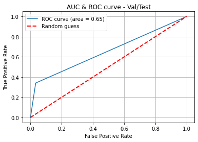

```
#Cv - Train: (5, 5) - Test: (5, 5)

Train and test scores according to the sample size

Train: [1.         1.         1.         0.99616182 0.99772961]
Test:  [0.5835582  0.58007465 0.59389619 0.58663139 0.61175346]
```

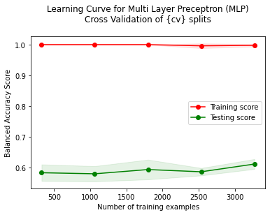

```python
n_feat = 15

param_grid = {'hidden_layer_sizes': [(30, 30, 30, 30)]}

avalia_scenario(X_train_all, X_val_all, y_train, y_val, df_results, n_feat, 'U30-15', param_grid, scen=0)
```

```python
df_results
```

|  | Scenarios | #Features | Train/Test | Acc | Bal_Acc | M_P | M_R | M_F1 | P0 | P1 | R0 | R1 | MSE | Auc |
| --- | --- | --- | --- | --- | --- | --- | --- | --- | --- | --- | --- | --- | --- | --- |
| 1 | Set-00 | 21 features | Train | 0.98 | 0.76 | 0.95 | 0.76 | 0.83 | 0.98 | 0.92 | 1.00 | 0.52 | 0.017 | 0.76 |
| 2 | Set-00 | 21 features | Val/Test | 0.97 | 0.62 | 0.74 | 0.62 | 0.66 | 0.98 | 0.50 | 0.99 | 0.25 | 0.032 | 0.62 |
| 3 | param_grid | 21 features | Train | 0.99 | 0.82 | 0.96 | 0.82 | 0.88 | 0.99 | 0.92 | 1.00 | 0.64 | 0.013 | 0.82 |
| 4 | param_grid | 21 features | Val/Test | 0.96 | 0.63 | 0.69 | 0.63 | 0.66 | 0.98 | 0.41 | 0.99 | 0.27 | 0.036 | 0.63 |
| 5 | NN0-05 | 5 features | Train | 0.97 | 0.50 | 0.48 | 0.50 | 0.49 | 0.97 | 0.00 | 1.00 | 0.00 | 0.032 | 0.50 |
| 6 | NN0-05 | 5 features | Val/Test | 0.97 | 0.50 | 0.48 | 0.50 | 0.49 | 0.97 | 0.00 | 1.00 | 0.00 | 0.032 | 0.50 |
| 7 | NN0-10 | 10 features | Train | 0.97 | 0.55 | 0.73 | 0.55 | 0.57 | 0.97 | 0.48 | 1.00 | 0.10 | 0.033 | 0.55 |
| 8 | NN0-10 | 10 features | Val/Test | 0.97 | 0.59 | 0.89 | 0.59 | 0.64 | 0.97 | 0.80 | 1.00 | 0.18 | 0.028 | 0.59 |
| 9 | NN0-15 | 15 features | Train | 0.97 | 0.58 | 0.78 | 0.58 | 0.62 | 0.97 | 0.58 | 1.00 | 0.17 | 0.031 | 0.58 |
| 10 | NN0-15 | 15 features | Val/Test | 0.97 | 0.61 | 0.82 | 0.61 | 0.66 | 0.97 | 0.67 | 1.00 | 0.23 | 0.029 | 0.61 |
| 11 | NN0-21 | 21 features | Train | 0.98 | 0.76 | 0.95 | 0.76 | 0.83 | 0.98 | 0.92 | 1.00 | 0.52 | 0.017 | 0.76 |
| 12 | NN0-21 | 21 features | Val/Test | 0.97 | 0.62 | 0.74 | 0.62 | 0.66 | 0.98 | 0.50 | 0.99 | 0.25 | 0.032 | 0.62 |
| 13 | hid-10 | 10 features | Train | 0.98 | 0.81 | 0.89 | 0.81 | 0.84 | 0.99 | 0.78 | 0.99 | 0.63 | 0.018 | 0.81 |
| 14 | hid-10 | 10 features | Val/Test | 0.96 | 0.63 | 0.64 | 0.63 | 0.63 | 0.98 | 0.30 | 0.98 | 0.27 | 0.044 | 0.63 |
| 15 | hid-15 | 15 features | Train | 0.99 | 0.95 | 0.91 | 0.95 | 0.93 | 1.00 | 0.82 | 0.99 | 0.90 | 0.010 | 0.95 |
| 16 | hid-15 | 15 features | Val/Test | 0.96 | 0.66 | 0.65 | 0.66 | 0.66 | 0.98 | 0.33 | 0.98 | 0.34 | 0.044 | 0.66 |
| 17 | hid-21 | 21 features | Train | 1.00 | 0.99 | 1.00 | 0.99 | 1.00 | 1.00 | 1.00 | 1.00 | 0.98 | 0.000 | 0.99 |
| 18 | hid-21 | 21 features | Val/Test | 0.95 | 0.59 | 0.61 | 0.59 | 0.60 | 0.97 | 0.24 | 0.98 | 0.20 | 0.047 | 0.59 |
| 19 | reg-15 | 15 features | Train | 0.99 | 0.95 | 0.91 | 0.95 | 0.93 | 1.00 | 0.82 | 0.99 | 0.90 | 0.010 | 0.95 |
| 20 | reg-15 | 15 features | Val/Test | 0.96 | 0.66 | 0.65 | 0.66 | 0.66 | 0.98 | 0.33 | 0.98 | 0.34 | 0.044 | 0.66 |
| 21 | U30-15 | 15 features | Train | 0.99 | 0.99 | 0.92 | 0.99 | 0.95 | 1.00 | 0.84 | 0.99 | 0.98 | 0.007 | 0.99 |
| 22 | U30-15 | 15 features | Val/Test | 0.95 | 0.65 | 0.62 | 0.65 | 0.63 | 0.98 | 0.25 | 0.97 | 0.34 | 0.054 | 0.65 |

The best result until the moment it was the MLP with 4 Hidden layers and 15 features. However, these models presents problems with imbalanced data. As the classes of our model are strongly imbalanced, the model tends to learn the most common class (class 0 - not bankrupt) and it doesn’t abstract information from the other class.

Below are the results using the test set.

```
Best parameters found:
 {'hidden_layer_sizes': (15, 15, 15, 15)}
0.638 (+/-0.016) for {'hidden_layer_sizes': (15, 15, 15, 15)}
Confusion matrix - Val/Test:
```

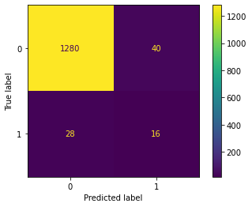

```
Classification Report - Val/Test:
              precision    recall  f1-score   support

           0       0.98      0.97      0.97      1320
           1       0.29      0.36      0.32        44

    accuracy                           0.95      1364
   macro avg       0.63      0.67      0.65      1364
weighted avg       0.96      0.95      0.95      1364


MSE - {type_set}: 0.05
```

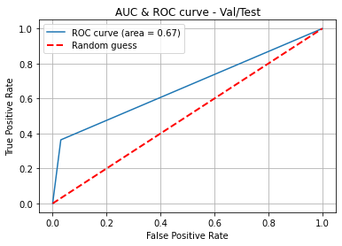

```
#Cv - Train: (5, 5) - Test: (5, 5)

Train and test scores according to the sample size

Train: [0.96923077 0.98888404 0.99810345 0.98066983 0.93549302]
Test:  [0.59766305 0.60947929 0.60719813 0.60960683 0.62387499]
```

```python
n_feat = 15

param_grid = {
        'hidden_layer_sizes': [(n_feat, n_feat, n_feat, n_feat)]}

avalia_scenario(X_train_all, X_test_all, y_train, y_test, df_results, n_feat, 'RES-15', param_grid)
```

```
Best parameters found:
 {'hidden_layer_sizes': (10, 10, 10, 10, 10)}
0.606 (+/-0.068) for {'hidden_layer_sizes': (10, 10, 10, 10, 10)}
Confusion matrix - Val/Test:
```

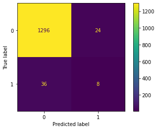

```
Classification Report - Val/Test:
              precision    recall  f1-score   support

           0       0.97      0.98      0.98      1320
           1       0.25      0.18      0.21        44

    accuracy                           0.96      1364
   macro avg       0.61      0.58      0.59      1364
weighted avg       0.95      0.96      0.95      1364


MSE - {type_set}: 0.044
```

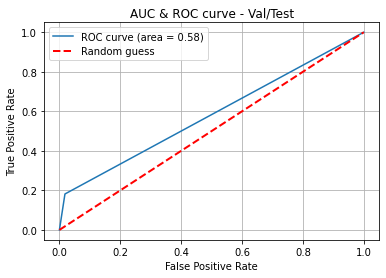

```
#Cv - Train: (5, 5) - Test: (5, 5)

Train and test scores according to the sample size

Train: [1.         0.96927016 0.86260794 0.79575217 0.78705806]
Test:  [0.58509957 0.59237944 0.60932873 0.59156487 0.59351533]
```

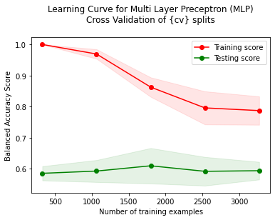

```python
n_feat = 10

param_grid = {
        'hidden_layer_sizes': [(n_feat, n_feat, n_feat, n_feat, n_feat)]}

avalia_scenario(X_train_all, X_test_all, y_train, y_test, df_results, n_feat, 'RES-10', param_grid)
```

```
Best parameters found:
 {'hidden_layer_sizes': (21, 21)}
0.654 (+/-0.065) for {'hidden_layer_sizes': (21, 21)}
Confusion matrix - Val/Test:
```

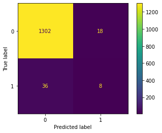

```
Classification Report - Val/Test:
              precision    recall  f1-score   support

           0       0.97      0.99      0.98      1320
           1       0.31      0.18      0.23        44

    accuracy                           0.96      1364
   macro avg       0.64      0.58      0.60      1364
weighted avg       0.95      0.96      0.96      1364


MSE - {type_set}: 0.04
```

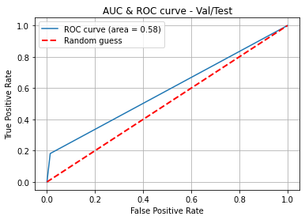

```
#Cv - Train: (5, 5) - Test: (5, 5)

Train and test scores according to the sample size

Train: [1.         1.         0.99830508 0.99244531 0.99228589]
Test:  [0.60741812 0.5871193  0.58655337 0.6129672  0.65024445]
```

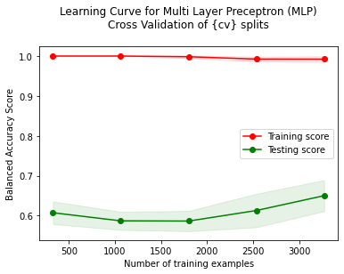

```python
n_feat = 21

param_grid = {
        'hidden_layer_sizes': [(n_feat, n_feat)]}

avalia_scenario(X_train_all, X_test_all, y_train, y_test, df_results, n_feat, 'RES-21', param_grid)
```

```python
df_results
```

|  | Scenarios | #Features | Train/Test | Acc | Bal_Acc | M_P | M_R | M_F1 | P0 | P1 | R0 | R1 | MSE | Auc |
| --- | --- | --- | --- | --- | --- | --- | --- | --- | --- | --- | --- | --- | --- | --- |
| 1 | Set-00 | 21 features | Train | 0.98 | 0.76 | 0.95 | 0.76 | 0.83 | 0.98 | 0.92 | 1.00 | 0.52 | 0.017 | 0.76 |
| 2 | Set-00 | 21 features | Val/Test | 0.97 | 0.62 | 0.74 | 0.62 | 0.66 | 0.98 | 0.50 | 0.99 | 0.25 | 0.032 | 0.62 |
| 3 | param_grid | 21 features | Train | 0.99 | 0.82 | 0.96 | 0.82 | 0.88 | 0.99 | 0.92 | 1.00 | 0.64 | 0.013 | 0.82 |
| 4 | param_grid | 21 features | Val/Test | 0.96 | 0.63 | 0.69 | 0.63 | 0.66 | 0.98 | 0.41 | 0.99 | 0.27 | 0.036 | 0.63 |
| 5 | NN0-05 | 5 features | Train | 0.97 | 0.50 | 0.48 | 0.50 | 0.49 | 0.97 | 0.00 | 1.00 | 0.00 | 0.032 | 0.50 |
| 6 | NN0-05 | 5 features | Val/Test | 0.97 | 0.50 | 0.48 | 0.50 | 0.49 | 0.97 | 0.00 | 1.00 | 0.00 | 0.032 | 0.50 |
| 7 | NN0-10 | 10 features | Train | 0.97 | 0.55 | 0.73 | 0.55 | 0.57 | 0.97 | 0.48 | 1.00 | 0.10 | 0.033 | 0.55 |
| 8 | NN0-10 | 10 features | Val/Test | 0.97 | 0.59 | 0.89 | 0.59 | 0.64 | 0.97 | 0.80 | 1.00 | 0.18 | 0.028 | 0.59 |
| 9 | NN0-15 | 15 features | Train | 0.97 | 0.58 | 0.78 | 0.58 | 0.62 | 0.97 | 0.58 | 1.00 | 0.17 | 0.031 | 0.58 |
| 10 | NN0-15 | 15 features | Val/Test | 0.97 | 0.61 | 0.82 | 0.61 | 0.66 | 0.97 | 0.67 | 1.00 | 0.23 | 0.029 | 0.61 |
| 11 | NN0-21 | 21 features | Train | 0.98 | 0.76 | 0.95 | 0.76 | 0.83 | 0.98 | 0.92 | 1.00 | 0.52 | 0.017 | 0.76 |
| 12 | NN0-21 | 21 features | Val/Test | 0.97 | 0.62 | 0.74 | 0.62 | 0.66 | 0.98 | 0.50 | 0.99 | 0.25 | 0.032 | 0.62 |
| 13 | hid-10 | 10 features | Train | 0.98 | 0.81 | 0.89 | 0.81 | 0.84 | 0.99 | 0.78 | 0.99 | 0.63 | 0.018 | 0.81 |
| 14 | hid-10 | 10 features | Val/Test | 0.96 | 0.63 | 0.64 | 0.63 | 0.63 | 0.98 | 0.30 | 0.98 | 0.27 | 0.044 | 0.63 |
| 15 | hid-15 | 15 features | Train | 0.99 | 0.95 | 0.91 | 0.95 | 0.93 | 1.00 | 0.82 | 0.99 | 0.90 | 0.010 | 0.95 |
| 16 | hid-15 | 15 features | Val/Test | 0.96 | 0.66 | 0.65 | 0.66 | 0.66 | 0.98 | 0.33 | 0.98 | 0.34 | 0.044 | 0.66 |
| 17 | hid-21 | 21 features | Train | 1.00 | 0.99 | 1.00 | 0.99 | 1.00 | 1.00 | 1.00 | 1.00 | 0.98 | 0.000 | 0.99 |
| 18 | hid-21 | 21 features | Val/Test | 0.95 | 0.59 | 0.61 | 0.59 | 0.60 | 0.97 | 0.24 | 0.98 | 0.20 | 0.047 | 0.59 |
| 19 | reg-15 | 15 features | Train | 0.99 | 0.95 | 0.91 | 0.95 | 0.93 | 1.00 | 0.82 | 0.99 | 0.90 | 0.010 | 0.95 |
| 20 | reg-15 | 15 features | Val/Test | 0.96 | 0.66 | 0.65 | 0.66 | 0.66 | 0.98 | 0.33 | 0.98 | 0.34 | 0.044 | 0.66 |
| 21 | U30-15 | 15 features | Train | 0.99 | 0.99 | 0.92 | 0.99 | 0.95 | 1.00 | 0.84 | 0.99 | 0.98 | 0.007 | 0.99 |
| 22 | U30-15 | 15 features | Val/Test | 0.95 | 0.65 | 0.62 | 0.65 | 0.63 | 0.98 | 0.25 | 0.97 | 0.34 | 0.054 | 0.65 |
| 23 | RES-15 | 15 features | Train | 0.99 | 0.95 | 0.91 | 0.95 | 0.93 | 1.00 | 0.82 | 0.99 | 0.90 | 0.010 | 0.95 |
| 24 | RES-15 | 15 features | Val/Test | 0.95 | 0.67 | 0.63 | 0.67 | 0.65 | 0.98 | 0.29 | 0.97 | 0.36 | 0.050 | 0.67 |
| 25 | RES-10 | 10 features | Train | 0.98 | 0.81 | 0.89 | 0.81 | 0.84 | 0.99 | 0.78 | 0.99 | 0.63 | 0.018 | 0.81 |
| 26 | RES-10 | 10 features | Val/Test | 0.96 | 0.58 | 0.61 | 0.58 | 0.59 | 0.97 | 0.25 | 0.98 | 0.18 | 0.044 | 0.58 |
| 27 | RES-21 | 21 features | Train | 1.00 | 0.99 | 1.00 | 0.99 | 1.00 | 1.00 | 1.00 | 1.00 | 0.98 | 0.000 | 0.99 |
| 28 | RES-21 | 21 features | Val/Test | 0.96 | 0.58 | 0.64 | 0.58 | 0.60 | 0.97 | 0.31 | 0.99 | 0.18 | 0.040 | 0.58 |

**Proposed solutions for imbalanced data**

*1. Stratified train-test split or stratified k-fold cross-validation*

The two most common approaches used for model evaluation are the train/test split and the k-fold cross-validation procedure. Both approaches can be very effective in general, although they can result in misleading results and potentially fail when used on classification problems with a severe class imbalanced. Instead, we modified to stratify the sampling by the class label, called stratified train-test split or stratified k-fold cross-validation.

Althoug stratification reduces the estimate’s variance, we prefered to use this approach to avoid problems with imbalanced data.

*2. Metrics change - from 'accuracy' to 'balanced accuracy'*

Balanced accuracy is a metric that one can use when evaluating how good a binary classifier is. It is especially useful when the classes are imbalanced, i.e. one of the two classes appears a lot more often than the other.

Other possibility it is to use: class_weight, sample_weight, however this solution are not available for Neural network.

*3. Re-sampling techniques*

One way of addressing this issue is by re-sampling the dataset as to offset this imbalance. It consists of removing samples from the majority class (under-sampling) and / or adding more examples from the minority class (over-sampling).

*- Random Oversampling Imbalanced Datasets*

RandomOverSampler: Object to over-sample the minority class(es) by picking samples at random with replacement. The bootstrap can be generated in a smoothed manner.

```python
df_results_resampling = pd.DataFrame(columns = ['Scenarios','#Features', 'Train/Test', 'Acc', 'Bal_Acc','M_P','M_R', 'M_F1', "P0", "P1", "R0", "R1", 'MSE', 'Auc'])
print (df_results)
```

```
Empty DataFrame
Columns: [Scenarios, #Features, Train/Test, Acc, Bal_Acc, M_P, M_R, M_F1, P0, P1, R0, R1, MSE, Auc]
Index: []
```

```python
def preprocessing_data(X_train_all, X_test_all, n_feat):

    '''Select the number of features in the split sets and apply feature scaling'''

    # selecting the number of features for X_train and X_test
    X_train = X_train_all.iloc[:,0:n_feat]
    X_test = X_test_all.iloc[:,0:n_feat] # selecting the number of features

    # feature scaling
    X_train, X_test = feature_scaling(X_train, X_test)

    return X_train, X_test

param_basic = {'hidden_layer_sizes': [n_feat], 'activation': ['relu'], 'solver': ['adam']}
def avalia_scenario_resampling(X_train, X_test, y_train, y_test, df_results_resampling, n_feat, scenario_name, param_grid=param_basic, scen=0):

    # Train neural network, selecting the best parameters when necessary
    clf, clf_grid, predict_train, predict_test = neural_network(X_train, y_train, X_test, param_grid) # training neural network

    # show the results of the scenarios and the best option when analyzing the parameters
    if scen==0:
        print_results_grid(clf_grid, predict_train, predict_test)

    # evaluate the model and include results in the spreadsheet
    evaluation_scenario(clf, y_train, y_test, predict_train, predict_test, df_results_resampling, scenario_name, n_feat) # evaluation model
    print_evaluation_scenario(clf, X_train, y_train, X_test, y_test, predict_train, predict_test)
    plot_learning_curve(clf, X_train, y_train)
    if scen==2:
        print_evaluation_scenario(clf, X_train, y_train, X_test, y_test, predict_train, predict_test) # print results
    print
```

```python
X_train_15, X_val_15 = preprocessing_data(X_train_all, X_val_all, 15)

#### define oversampling strategy
ros = RandomOverSampler(sampling_strategy='minority', random_state=42)
# fit and apply the transform
X_train_ros, y_train_ros = ros.fit_resample(X_train_15, y_train)
print('Resampled dataset shape %s' % Counter(y_train_ros))
```

```
Resampled dataset shape Counter({0: 3959, 1: 3959})
```

```
Best parameters found:
 {'hidden_layer_sizes': (15, 15, 15)}
0.946 (+/-0.011) for {'hidden_layer_sizes': 15}
0.979 (+/-0.003) for {'hidden_layer_sizes': (15, 15)}
0.984 (+/-0.004) for {'hidden_layer_sizes': (15, 15, 15)}
0.982 (+/-0.006) for {'hidden_layer_sizes': (15, 15, 15, 15)}
Confusion matrix - Val/Test:
```

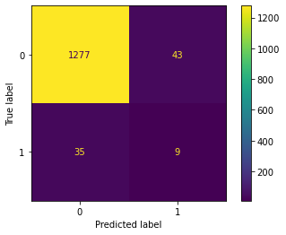

```
Classification Report - Val/Test:
              precision    recall  f1-score   support

           0       0.97      0.97      0.97      1320
           1       0.17      0.20      0.19        44

    accuracy                           0.94      1364
   macro avg       0.57      0.59      0.58      1364
weighted avg       0.95      0.94      0.95      1364


MSE - {type_set}: 0.057
```

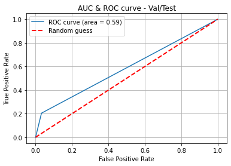

```
#Cv - Train: (5, 5) - Test: (5, 5)

Train and test scores according to the sample size

Train: [0.98095238 0.9934274  0.98401455 0.9989265  0.99760039]
Test:  [0.63274097 0.75853047 0.94973886 0.98269867 0.98421334]
```

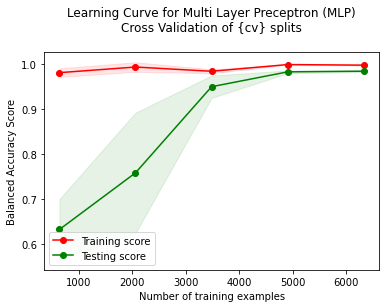

```python
n_feat = 15
param_grid = {'hidden_layer_sizes': [(n_feat), (n_feat, n_feat), (n_feat, n_feat, n_feat),(n_feat, n_feat, n_feat, n_feat)]}
avalia_scenario_resampling(X_train_ros, X_val_15, y_train_ros, y_val, df_results_resampling, n_feat, 'OVE-XHD-'+ str(n_feat), param_grid)
```

*-SMOTE algorithm (Synthetic Minority Oversampling Technique)*

[figure not shown]

Example of Smote

SMOTE (Synthetic Minority Oversampling TEchnique): consists of synthesizing elements for the minority class, based on those that already exist.

Specifically, a random example from the minority class is first chosen. Then k of the nearest neighbors for that example are found (typically k=5). A randomly selected neighbor is chosen and a synthetic example is created at a randomly selected point between the two examples in feature space.

```python
# define smote strategy
smo = SMOTE(sampling_strategy='minority', random_state=42)
# fit and apply the transform
X_train_smo, y_train_smo = smo.fit_resample(X_train_15, y_train)
print('Resampled dataset shape %s' % Counter(y_train_smo))
```

```
Resampled dataset shape Counter({0: 3959, 1: 3959})
```

```
Best parameters found:
 {'hidden_layer_sizes': (15, 15, 15)}
0.940 (+/-0.013) for {'hidden_layer_sizes': 15}
0.965 (+/-0.011) for {'hidden_layer_sizes': (15, 15)}
0.968 (+/-0.006) for {'hidden_layer_sizes': (15, 15, 15)}
0.965 (+/-0.006) for {'hidden_layer_sizes': (15, 15, 15, 15)}
Confusion matrix - Val/Test:
```

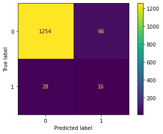

```
Classification Report - Val/Test:
              precision    recall  f1-score   support

           0       0.98      0.95      0.96      1320
           1       0.20      0.36      0.25        44

    accuracy                           0.93      1364
   macro avg       0.59      0.66      0.61      1364
weighted avg       0.95      0.93      0.94      1364


MSE - {type_set}: 0.069
```

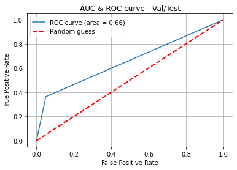

```
#Cv - Train: (5, 5) - Test: (5, 5)

Train and test scores according to the sample size

Train: [0.98095238 0.9934274  0.97740119 0.99346037 0.99188543]
Test:  [0.61733501 0.72228352 0.89252353 0.96148064 0.96842684]
```

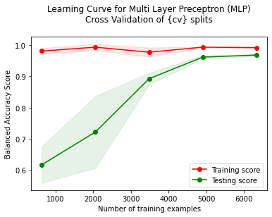

```python
n_feat = 15
param_grid = {'hidden_layer_sizes': [(n_feat), (n_feat, n_feat), (n_feat, n_feat, n_feat),(n_feat, n_feat, n_feat, n_feat)]}
avalia_scenario_resampling(X_train_smo, X_val_15, y_train_smo, y_val, df_results_resampling, n_feat, 'SMO-XHD-'+ str(n_feat), param_grid)
```

*- Undersampling*

```python
# define smote strategy
rus = RandomUnderSampler(random_state=42)
# fit and apply the transform
X_train_rus, y_train_rus = rus.fit_resample(X_train_15, y_train)

print('Resampled dataset shape %s' % Counter(y_train_rus))
```

```
Resampled dataset shape Counter({0: 132, 1: 132})
```

```
Best parameters found:
 {'hidden_layer_sizes': (15, 15, 15, 15)}
0.766 (+/-0.105) for {'hidden_layer_sizes': (15, 15, 15, 15)}
Confusion matrix - Val/Test:
```

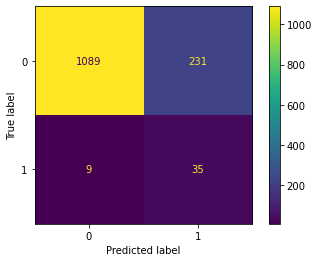

```
Classification Report - Val/Test:
              precision    recall  f1-score   support

           0       0.99      0.82      0.90      1320
           1       0.13      0.80      0.23        44

    accuracy                           0.82      1364
   macro avg       0.56      0.81      0.56      1364
weighted avg       0.96      0.82      0.88      1364


MSE - {type_set}: 0.176
```

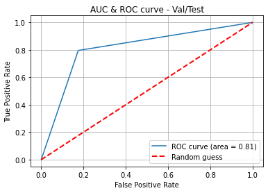

```
#Cv - Train: (5, 5) - Test: (5, 5)

Train and test scores according to the sample size

Train: [1.         1.         0.98090909 1.         0.9620575 ]
Test:  [0.5        0.5        0.62549858 0.76168091 0.76168091]
```

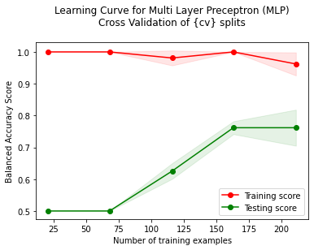

```python
n_feat = 15
param_grid = {'hidden_layer_sizes': [(n_feat, n_feat, n_feat, n_feat)]}
avalia_scenario_resampling(X_train_rus, X_val_15, y_train_rus, y_val, df_results_resampling, n_feat, 'RUS-'+ str(n_feat), param_grid)
```

```python
df_results_resampling
```

|  | Scenarios | #Features | Train/Test | Acc | Bal_Acc | M_P | M_R | M_F1 | P0 | P1 | R0 | R1 | MSE | Auc |
| --- | --- | --- | --- | --- | --- | --- | --- | --- | --- | --- | --- | --- | --- | --- |
| 1 | OVE-XHD-15 | 15 features | Train | 1.00 | 1.00 | 1.00 | 1.00 | 1.00 | 1.00 | 0.99 | 0.99 | 1.00 | 0.003 | 1.00 |
| 2 | OVE-XHD-15 | 15 features | Val/Test | 0.94 | 0.59 | 0.57 | 0.59 | 0.58 | 0.97 | 0.17 | 0.97 | 0.20 | 0.057 | 0.59 |
| 3 | SMO-XHD-15 | 15 features | Train | 0.99 | 0.99 | 0.99 | 0.99 | 0.99 | 1.00 | 0.98 | 0.98 | 1.00 | 0.010 | 0.99 |
| 4 | SMO-XHD-15 | 15 features | Val/Test | 0.93 | 0.66 | 0.59 | 0.66 | 0.61 | 0.98 | 0.20 | 0.95 | 0.36 | 0.069 | 0.66 |
| 5 | RUS-15 | 15 features | Train | 1.00 | 1.00 | 1.00 | 1.00 | 1.00 | 1.00 | 1.00 | 1.00 | 1.00 | 0.000 | 1.00 |
| 6 | RUS-15 | 15 features | Val/Test | 0.82 | 0.81 | 0.56 | 0.81 | 0.56 | 0.99 | 0.13 | 0.82 | 0.80 | 0.176 | 0.81 |

We notice that even using these strategies of oversampling, smote and under sampling, the results are a little worse than without oversampling. Seeking a balanced distribution for a severely imbalanced dataset can lead algorithms to overfit the minority class, increasing generalization error. The effect can be better performance on the training dataset, but worse performance on the holdout or test dataset.

Despite the advantage of balancing classes, these techniques also have their weaknesses.

- The implementation of over-sampling duplicates random records from the minority class, which can cause overfitting.
- Smote use kNN to creates new synthetic samples, however this technique can generate samples that does not represent the reality, mainly in cases that the variation within the minority class is very high.
- In under-sampling, the technique involves removing random records from the majority class, which can cause loss of information.

These results can happen if there are many variations within the minority class and many similarities between the two classes.

We can try to observe this testing alternatives as One class SVM and DBSCan.

To solve this problems we tried:

- weight the classes, making your model preferential to the minority class (not alllowed in standard NN).
- Under-sampling/ oversampling techniques.

In the next notebook we will try reach our goal to trying to predict the minority class using outlier detection techniques.